# `tidyplots`: Data Visualisation Made Simple(R)

## 4.5 Violin plot

- A more ‘contemporary’ version of the boxplot. Displays continuous distribution of a variable for the different categories of the qualitative variable.

```r
df.pen %>%
  tidyplot(x = State, y = BNvoteshare) %>%
  add_violin() %>%
  add_data_points_jitter()
```

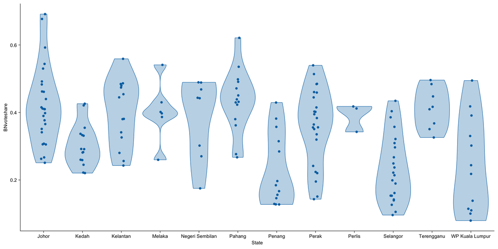

## 4.6 Scatter plot

### Scatter plot

- Scatter plots depict association between 2 continuous variables.
- Lets see the relationship between BN vote share and the constituencies’ Malay population share.

```r
df.pen %>%
  tidyplot(x = Malay, y = BNvoteshare) %>%
  add_data_points(size = 2)
```

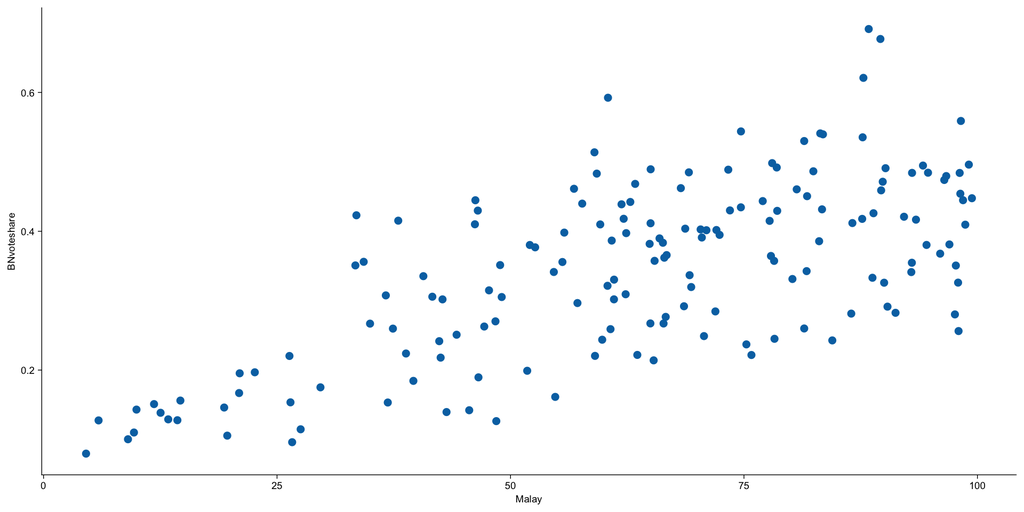

### Scatter plot with line of best fit

- To include the line of best fit, we use the `add_curve_fit()` function and specify the `method` argument as `lm` (linear model). Otherwise, the default `method` is `loess`.

```r
df.pen %>%
  tidyplot(x = Malay, y = BNvoteshare) %>%
  add_data_points(size = 2) %>%
  add_curve_fit(method = "lm")
```

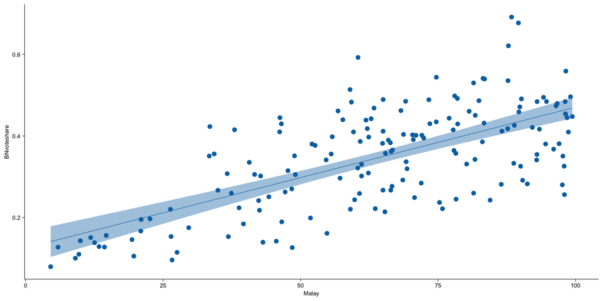

## 4.7 Global vs Local Mapping

- The `ggplot()` function allows flexibility in global and local mapping, allowing for different aesthics in different layers.
- For example, look at the difference between these 2 code chunks:

```r
#Global mapping
ggplot(df.pen, aes(x = Malay,
                   y = BNvoteshare,
                   col = Urbanisation)) +
  geom_point() +
  geom_smooth(method = "lm")

#Local mapping for geom_point
ggplot(df.pen, aes(x = Malay,
                   y = BNvoteshare)) +
  geom_point(aes(col = Urbanisation)) +
  geom_smooth(method = "lm")
```

- The `x`, `y` and other visual elements (e.g. `size`, `col`, `fill`) specified in the `tidyplot()` function are regarded as global mapping. However, to have a local mapping for a specific graphical layer that overwrites the global mapping using the `tidyplots` framework, we will need to `add()` the relevant `geom_*()` function from the `ggplot2` package.

### Global mapping

- To have the scatter points and regression lines coloured for each of the urbanisation groups,

```r
df.pen %>%
  tidyplot(x = Malay, y = BNvoteshare, col = Urbanisation) %>%
  add_data_points(size = 2) %>%
  add_curve_fit(method = "lm")
```

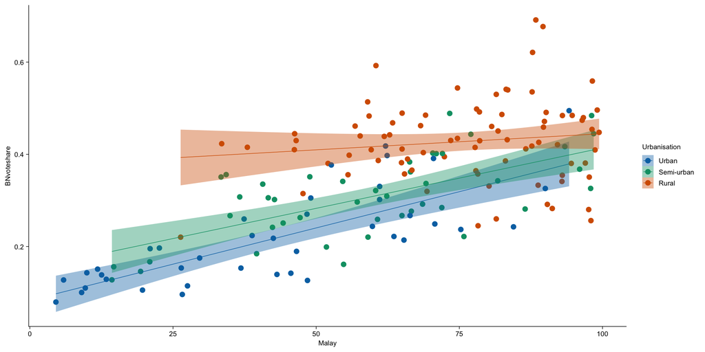

- To have the scatter points coloured for each of the urbanisation groups, but an overall regression line for all data points, we `add` the `geom_smooth()` function from the `ggplot2` package.

```r
df.pen %>%
  tidyplot(x = Malay, y = BNvoteshare, color = Urbanisation) %>%
  add_data_points(size = 2) %>%
  add(
    geom_smooth(aes(x = Malay, y = BNvoteshare),
    method = "lm",
    inherit.aes = F
  ))
```

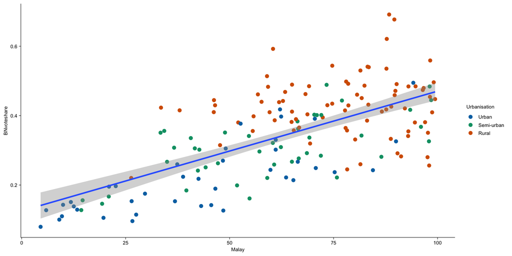

- The parent `tidyplot()` has `color = Urbanisation` — this implicitly groups the data by `Urbanisation`.
- Without `inherit.aes = FALSE`, `geom_smooth()` would inherit that grouping and draw one line per group.
- With `inherit.aes = FALSE`, `geom_smooth()` only sees `aes(x = Malay, y = BNvoteshare)` — no grouping, so it draws one line through all the data.

## 4.8 Facets (Multiple Plots)

- Concept of small multiples.
- The idea of conditioning on the values taken on by one more of the **categorical** variables in a data set.
- Created by adding the layer `facet_grid()` in the `ggplot2` package
- In `tidyplots`, we use `split_plot()`.

### Split by one variable

- Display the relationship between Malay population share and BN vote share in each of the urbanisation classification:

```r
df.pen %>%
  tidyplot(x = Malay, y = BNvoteshare) %>%
  add_data_points() %>%
  add_curve_fit(method = "lm") %>%
  split_plot(by = Urbanisation)
```

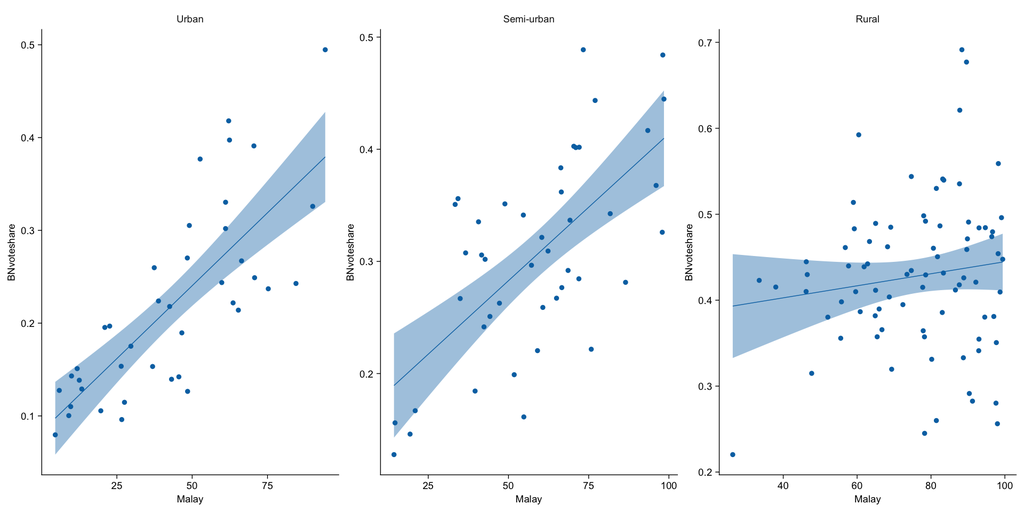

- In `ggplot`, the scales of the y and x axis are fixed by default. The reverse is true for `tidyplot`.
- Similar to the `ggplot`, use the `scales` argument to modify the y and/or x axis. The options are `fixed`, `free_y`, or `free_x`. These options have the same syntax used in `ggplot`.

```r
df.pen %>%
  tidyplot(x = Malay, y = BNvoteshare) %>%
  add_data_points() %>%
  add_curve_fit(method = "lm") %>%
  split_plot(by = Urbanisation, scales = "fixed")
```

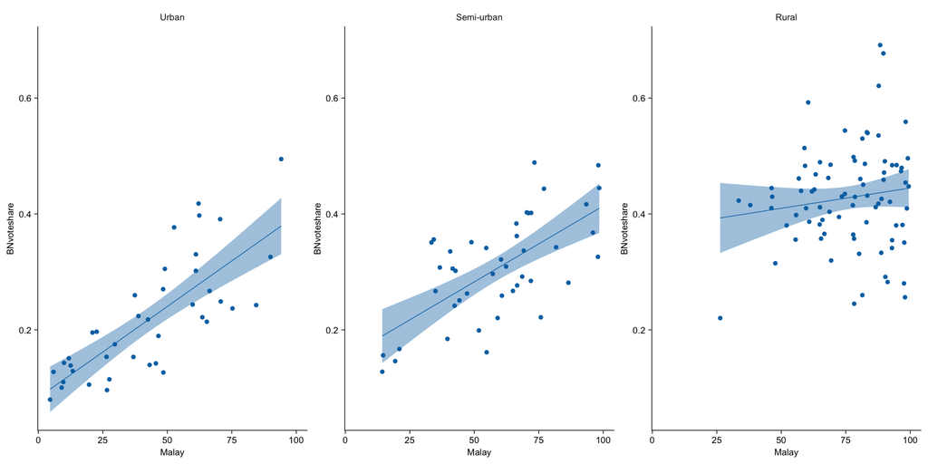

### Split by two variables

- To split the plots by 2 variables, specify the variables to the respective `rows` and `cols` arguments.

```r
df.pen %>%
  tidyplot(x = Malay, y = BNvoteshare) %>%
  add_data_points() %>%
  add_curve_fit(method = "lm") %>%
  split_plot(rows = Urbanisation, cols = Winner)
```

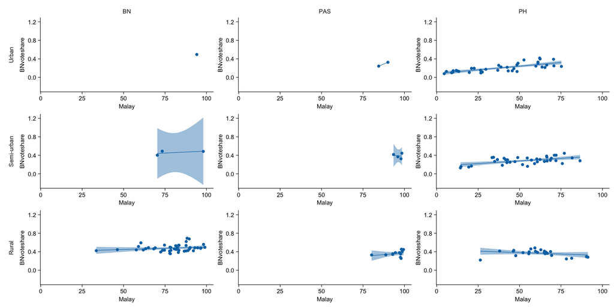